# F9_03_PROG_GRANT

Program accomplishment grants and allocations to others · Amount report

## Overview

**Description**

Program Accomplishment Grants

**Table**

**Location code**

`F990-PC-PART-03-LINE-04-ABCD`, `F990-EZ-PART-03-LINE-28-31`

**Family**

`F990-PC-PART-03-LINE-04-ABCD` · siblings: F9_03_PROG_CODE, F9_03_PROG_DESC, F9_03_PROG_EXP, F9_03_PROG_REV, F9_03_PROG_EXP_OTH_TOT, F9_03_PROG_GRANT_OTH_TOT

**Data type**

numeric (xsd: USAmountType, , USAmountNNType)

**Scope**

PZ

**Status**

unreviewed

20

xpaths mapped (10 observed)

2,853,190

filings with a value

2009–2024

tax years observed

19

open flags (1 errors)

## Flags

[output not shown]

## Xpaths

All mapped xpaths (under /Return/ReturnData or /Return/ReturnHeader), oldest first. Charts label each series by its xpath.

| Xpath | Form | Chart label | First year | Last year | Versions | Filings | Repeats in |
| --- | --- | --- | --- | --- | --- | --- | --- |
| IRS990EZ/ProgramServiceAccomplishment/GrantsAndAllocations | 990-EZ | same | 2009 | 2012 | 18 | 130,484 | 26.0% |
| IRS990/Grants | 990 | same | 2009 | 2012 | 18 | 111,680 | 0.0% |
| IRS990/Activity2/Grants | 990 | same | 2009 | 2012 | 18 | 34,079 | 0.0% |
| IRS990/Activity3/Grants | 990 | same | 2009 | 2012 | 18 | 23,131 | 0.0% |
| IRS990/ActivityOther/Grants | 990 | same | 2009 | 2012 | 16 | 14,275 | 19.1% |
| IRS990EZ/ProgramSrvcAccomplishmentGrp/GrantsAndAllocationsAmt | 990-EZ | …90EZ/ProgramSrvcAccomplishmentGrp/GrantsAndAllocationsAmt | 2013 | 2024 | 37 | 990,979 | 26.5% |
| IRS990/GrantAmt | 990 | same | 2013 | 2024 | 37 | 954,393 | 0.0% |
| IRS990/Form990PartIII/Activity2/Grants | 990 | Other |  |  |  | 0 |  |
| IRS990/Form990PartIII/Activity3/Grants | 990 | Other |  |  |  | 0 |  |
| IRS990/Form990PartIII/ActivityOther/Grants | 990 | Other |  |  |  | 0 |  |
| IRS990/Form990PartIII/Grants | 990 | Other |  |  |  | 0 |  |
| IRS990/ProgSrvcAccomActy2Grp/GrantAmt | 990 | Other | 2013 | 2024 | 37 | 288,647 | 0.0% |
| IRS990/ProgSrvcAccomActy3Grp/GrantAmt | 990 | Other | 2013 | 2024 | 37 | 199,798 | 0.0% |
| IRS990/ProgSrvcAccomActyOtherGrp/GrantAmt | 990 | Other | 2013 | 2024 | 37 | 105,724 | 17.5% |
| IRS990/ProgramServiceAccomplishments/GrantsAndAllocations | 990 | Other |  |  |  | 0 |  |
| IRS990EZ/GrantAmt | 990-EZ | Other |  |  |  | 0 |  |
| IRS990EZ/Grants | 990-EZ | Other |  |  |  | 0 |  |
| IRS990EZ/ProgSrvcAccomActy2Grp/GrantAmt | 990-EZ | Other |  |  |  | 0 |  |
| IRS990EZ/ProgSrvcAccomActy3Grp/GrantAmt | 990-EZ | Other |  |  |  | 0 |  |
| IRS990EZ/ProgSrvcAccomActyOtherGrp/GrantAmt | 990-EZ | Other |  |  |  | 0 |  |

## Coverage

[figure not shown]

**Table view**

Table view: filings by tax year and series

| Tax year | IRS990EZ/ProgramServiceAccomplishment/GrantsAndAllocations | IRS990/Grants | IRS990/Activity2/Grants | IRS990/Activity3/Grants | IRS990/ActivityOther/Grants | …90EZ/ProgramSrvcAccomplishmentGrp/GrantsAndAllocationsAmt | IRS990/GrantAmt | Other |
| --- | --- | --- | --- | --- | --- | --- | --- | --- |
| 2009 | 9,510 | 9,192 | 3,014 | 2,193 | 1,395 | 0 | 0 | 0 |
| 2010 | 33,196 | 27,387 | 8,602 | 5,896 | 3,468 | 0 | 0 | 0 |
| 2011 | 41,709 | 34,008 | 10,365 | 6,979 | 4,147 | 0 | 0 | 0 |
| 2012 | 46,069 | 41,093 | 12,098 | 8,063 | 5,265 | 0 | 0 | 0 |
| 2013 | 0 | 0 | 0 | 0 | 0 | 56,829 | 45,813 | 27,975 |
| 2014 | 0 | 0 | 0 | 0 | 0 | 62,950 | 50,722 | 30,785 |
| 2015 | 0 | 0 | 0 | 0 | 0 | 66,766 | 54,452 | 32,617 |
| 2016 | 0 | 0 | 0 | 0 | 0 | 67,604 | 57,571 | 33,937 |
| 2017 | 0 | 0 | 0 | 0 | 0 | 70,923 | 62,660 | 36,580 |
| 2018 | 0 | 0 | 0 | 0 | 0 | 85,459 | 78,593 | 45,303 |
| 2019 | 0 | 0 | 0 | 0 | 0 | 86,895 | 83,735 | 48,812 |
| 2020 | 0 | 0 | 0 | 0 | 0 | 96,923 | 99,454 | 61,991 |
| 2021 | 0 | 0 | 0 | 0 | 0 | 107,281 | 105,959 | 67,024 |
| 2022 | 0 | 0 | 0 | 0 | 0 | 100,398 | 111,434 | 72,287 |
| 2023 | 0 | 0 | 0 | 0 | 0 | 100,550 | 114,741 | 75,983 |
| 2024 | 0 | 0 | 0 | 0 | 0 | 88,401 | 89,259 | 60,875 |

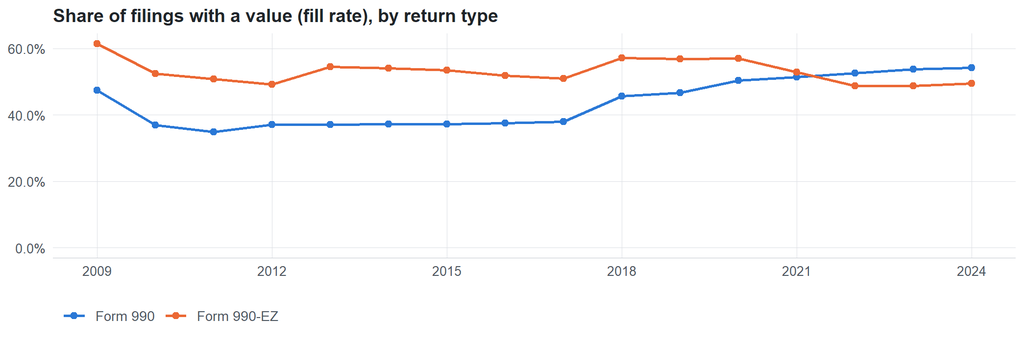

**Table view**

Table view: fill rate

| Tax year | Return type | Filings | All filings | Fill rate |
| --- | --- | --- | --- | --- |
| 2009 | Form 990 | 15,794 | 33,311 | 47.41% |
| 2009 | Form 990-EZ | 9,510 | 15,470 | 61.47% |
| 2010 | Form 990 | 45,353 | 123,025 | 36.86% |
| 2010 | Form 990-EZ | 33,196 | 63,326 | 52.42% |
| 2011 | Form 990 | 55,499 | 159,504 | 34.79% |
| 2011 | Form 990-EZ | 41,709 | 82,048 | 50.83% |
| 2012 | Form 990 | 66,519 | 179,688 | 37.02% |
| 2012 | Form 990-EZ | 46,069 | 93,750 | 49.14% |
| 2013 | Form 990 | 73,788 | 198,855 | 37.11% |
| 2013 | Form 990-EZ | 56,829 | 104,375 | 54.45% |
| 2014 | Form 990 | 81,507 | 218,619 | 37.28% |
| 2014 | Form 990-EZ | 62,950 | 116,417 | 54.07% |
| 2015 | Form 990 | 87,069 | 233,519 | 37.29% |
| 2015 | Form 990-EZ | 66,766 | 124,894 | 53.46% |
| 2016 | Form 990 | 91,508 | 243,903 | 37.52% |
| 2016 | Form 990-EZ | 67,604 | 130,484 | 51.81% |
| 2017 | Form 990 | 99,240 | 261,612 | 37.93% |
| 2017 | Form 990-EZ | 70,922 | 139,144 | 50.97% |
| 2018 | Form 990 | 123,896 | 271,442 | 45.64% |
| 2018 | Form 990-EZ | 85,459 | 149,384 | 57.21% |
| 2019 | Form 990 | 132,547 | 283,694 | 46.72% |
| 2019 | Form 990-EZ | 86,895 | 152,622 | 56.93% |
| 2020 | Form 990 | 161,442 | 320,342 | 50.40% |
| 2020 | Form 990-EZ | 96,923 | 169,864 | 57.06% |
| 2021 | Form 990 | 172,979 | 336,480 | 51.41% |
| 2021 | Form 990-EZ | 107,280 | 202,724 | 52.92% |
| 2022 | Form 990 | 183,718 | 349,055 | 52.63% |
| 2022 | Form 990-EZ | 100,398 | 206,130 | 48.71% |
| 2023 | Form 990 | 190,723 | 354,768 | 53.76% |
| 2023 | Form 990-EZ | 100,550 | 206,379 | 48.72% |
| 2024 | Form 990 | 150,134 | 277,298 | 54.14% |
| 2024 | Form 990-EZ | 88,401 | 178,867 | 49.42% |

## Repeating groups

Repeating element each xpath was observed in (from the raw indexed xpath)

| Xpath | Repeating element | Filings (summed over years) |
| --- | --- | --- |
| IRS990/Activity2/Grants | (none) | 34079 |
| IRS990/Activity3/Grants | (none) | 23131 |
| IRS990/ActivityOther/Grants | (none) | 10165 |
| IRS990/ActivityOther/Grants | IRS990/ActivityOther | 4110 |
| IRS990/Grants | (none) | 111680 |
| IRS990EZ/ProgramServiceAccomplishment/GrantsAndAllocations | (none) | 91252 |
| IRS990EZ/ProgramServiceAccomplishment/GrantsAndAllocations | IRS990EZ/ProgramServiceAccomplishment | 39232 |
| IRS990/GrantAmt | (none) | 954393 |
| IRS990/ProgSrvcAccomActy2Grp/GrantAmt | (none) | 288647 |
| IRS990/ProgSrvcAccomActy3Grp/GrantAmt | (none) | 199798 |
| IRS990/ProgSrvcAccomActyOtherGrp/GrantAmt | (none) | 80876 |
| IRS990/ProgSrvcAccomActyOtherGrp/GrantAmt | IRS990/ProgSrvcAccomActyOtherGrp | 24848 |
| IRS990EZ/ProgramSrvcAccomplishmentGrp/GrantsAndAllocationsAmt | (none) | 689844 |
| IRS990EZ/ProgramSrvcAccomplishmentGrp/GrantsAndAllocationsAmt | IRS990EZ/ProgramSrvcAccomplishmentGrp | 301135 |

## Values

| Result | Check | Detail |
| --- | --- | --- |
| ✓ pass | Values parse as numbers | 100.0% of values are numeric |
| ▲ warn | No sudden change in the median between adjacent years | largest change 13.0x (…90EZ/ProgramSrvcAccomplishmentGrp/GrantsAndAllocationsAmt, 990EZ, TY2018) |
| ▲ warn | Pooled xpaths are on the same scale (same return type) | medians differ 5.2x (990: IRS990/Grants vs IRS990/ActivityOther/Grants) |
| ⓘ info | Sign convention | 0.0% of values are negative (fine for net amounts) |

[figure not shown]

**Table view**

Table view: quartiles by tax year

| Series | Return | Tax year | Filings | P25 | Median | P75 |
| --- | --- | --- | --- | --- | --- | --- |
| IRS990EZ/ProgramServiceAccomplishment/GrantsAndAllocations | 990EZ | 2009 | 9,510 | 250.70 | 1,373 | 16,026 |
| IRS990EZ/ProgramServiceAccomplishment/GrantsAndAllocations | 990EZ | 2010 | 33,196 | 21.14 | 1,921 | 14,737 |
| IRS990EZ/ProgramServiceAccomplishment/GrantsAndAllocations | 990EZ | 2011 | 41,709 | 12.89 | 382.78 | 13,999 |
| IRS990EZ/ProgramServiceAccomplishment/GrantsAndAllocations | 990EZ | 2012 | 46,069 | 197.31 | 3,558 | 16,777 |
| IRS990/Grants | 990 | 2009 | 9,192 | 22,764 | 220,433 | 1,519,383 |
| IRS990/Grants | 990 | 2010 | 27,387 | 6,929 | 87,465 | 581,324 |
| IRS990/Grants | 990 | 2011 | 34,008 | 11,488 | 95,221 | 535,398 |
| IRS990/Grants | 990 | 2012 | 41,093 | 10,410 | 83,566 | 437,251 |
| IRS990/Activity2/Grants | 990 | 2009 | 3,014 | 4,613 | 65,670 | 508,336 |
| IRS990/Activity2/Grants | 990 | 2010 | 8,602 | 749.99 | 29,287 | 235,193 |
| IRS990/Activity2/Grants | 990 | 2011 | 10,365 | 3,095 | 34,340 | 224,992 |
| IRS990/Activity2/Grants | 990 | 2012 | 12,098 | 4,858 | 35,162 | 209,567 |
| IRS990/Activity3/Grants | 990 | 2009 | 2,193 | 1,844 | 46,272 | 321,597 |
| IRS990/Activity3/Grants | 990 | 2010 | 5,896 | 159.80 | 17,802 | 176,291 |
| IRS990/Activity3/Grants | 990 | 2011 | 6,979 | 816.04 | 23,310 | 165,072 |
| IRS990/Activity3/Grants | 990 | 2012 | 8,063 | 2,579 | 22,079 | 145,645 |
| IRS990/ActivityOther/Grants | 990 | 2009 | 1,395 | 4,552 | 36,513 | 241,153 |
| IRS990/ActivityOther/Grants | 990 | 2010 | 3,468 | 52.88 | 13,319 | 137,415 |
| IRS990/ActivityOther/Grants | 990 | 2011 | 4,147 | 709.25 | 18,061 | 128,264 |
| IRS990/ActivityOther/Grants | 990 | 2012 | 5,265 | 1,916 | 17,744 | 114,400 |
| …90EZ/ProgramSrvcAccomplishmentGrp/GrantsAndAllocationsAmt | 990EZ | 2013 | 56,829 | 1,824 | 7,213 | 23,927 |
| …90EZ/ProgramSrvcAccomplishmentGrp/GrantsAndAllocationsAmt | 990EZ | 2014 | 62,950 | 0 | 1,776 | 21,402 |
| …90EZ/ProgramSrvcAccomplishmentGrp/GrantsAndAllocationsAmt | 990EZ | 2015 | 66,766 | 1,569 | 6,627 | 23,173 |
| …90EZ/ProgramSrvcAccomplishmentGrp/GrantsAndAllocationsAmt | 990EZ | 2016 | 67,604 | 44.27 | 1,704 | 21,949 |
| …90EZ/ProgramSrvcAccomplishmentGrp/GrantsAndAllocationsAmt | 990EZ | 2017 | 70,922 | 407.06 | 5,864 | 25,472 |
| …90EZ/ProgramSrvcAccomplishmentGrp/GrantsAndAllocationsAmt | 990EZ | 2018 | 85,459 | 1.58 | 449.94 | 18,093 |
| …90EZ/ProgramSrvcAccomplishmentGrp/GrantsAndAllocationsAmt | 990EZ | 2019 | 86,895 | 0 | 2,953 | 17,012 |
| …90EZ/ProgramSrvcAccomplishmentGrp/GrantsAndAllocationsAmt | 990EZ | 2020 | 96,923 | 0 | 1,513 | 11,940 |
| …90EZ/ProgramSrvcAccomplishmentGrp/GrantsAndAllocationsAmt | 990EZ | 2021 | 107,280 | 0 | 0 | 5,240 |
| …90EZ/ProgramSrvcAccomplishmentGrp/GrantsAndAllocationsAmt | 990EZ | 2022 | 100,398 | 0 | 0 | 3,948 |
| …90EZ/ProgramSrvcAccomplishmentGrp/GrantsAndAllocationsAmt | 990EZ | 2023 | 100,550 | 0 | 0 | 3,931 |
| …90EZ/ProgramSrvcAccomplishmentGrp/GrantsAndAllocationsAmt | 990EZ | 2024 | 88,401 | 0 | 0 | 4,312 |
| IRS990/GrantAmt | 990 | 2013 | 45,813 | 10,663 | 88,649 | 497,802 |
| IRS990/GrantAmt | 990 | 2014 | 50,722 | 10,776 | 86,223 | 482,716 |
| IRS990/GrantAmt | 990 | 2015 | 54,452 | 10,698 | 86,912 | 478,237 |
| IRS990/GrantAmt | 990 | 2016 | 57,571 | 9,699 | 79,860 | 421,190 |
| IRS990/GrantAmt | 990 | 2017 | 62,660 | 13,545 | 90,048 | 459,782 |
| IRS990/GrantAmt | 990 | 2018 | 78,593 | 1,640 | 45,839 | 324,240 |
| IRS990/GrantAmt | 990 | 2019 | 83,735 | 2,786 | 46,974 | 341,283 |
| IRS990/GrantAmt | 990 | 2020 | 99,453 | 2,014 | 39,146 | 328,582 |
| IRS990/GrantAmt | 990 | 2021 | 105,957 | 4,060 | 51,238 | 331,347 |
| IRS990/GrantAmt | 990 | 2022 | 111,432 | 0 | 30,064 | 264,775 |
| IRS990/GrantAmt | 990 | 2023 | 114,740 | 0 | 33,944 | 313,218 |
| IRS990/GrantAmt | 990 | 2024 | 89,259 | 1,063 | 34,232 | 274,139 |
| Other | 990 | 2013 | 27,975 | 1,950 | 25,285 | 169,794 |
| Other | 990 | 2014 | 30,785 | 1,795 | 24,064 | 158,607 |
| Other | 990 | 2015 | 32,617 | 1,922 | 25,184 | 159,700 |
| Other | 990 | 2016 | 33,937 | 2,012 | 24,134 | 151,379 |
| Other | 990 | 2017 | 36,580 | 4,329 | 30,079 | 164,011 |
| Other | 990 | 2018 | 45,303 | 404.00 | 13,478 | 111,347 |
| Other | 990 | 2019 | 48,812 | 137.88 | 10,816 | 105,813 |
| Other | 990 | 2020 | 61,989 | 233.81 | 7,678 | 94,386 |
| Other | 990 | 2021 | 67,022 | 554.99 | 12,634 | 102,591 |
| Other | 990 | 2022 | 72,286 | 0 | 2,288 | 61,020 |
| Other | 990 | 2023 | 75,983 | 0 | 2,954 | 70,522 |
| Other | 990 | 2024 | 60,875 | 48.92 | 5,892 | 62,825 |

Summary by xpath and return type (all years)

| Series | Return | Filings | % numeric | % zero | % negative | Median (typical year) | P99 (typical year) |
| --- | --- | --- | --- | --- | --- | --- | --- |
| IRS990EZ/ProgramServiceAccomplishment/GrantsAndAllocations | 990EZ | 130,484 | 100 | 49.3 | 0 | 2715 | 145226 |
| IRS990/Grants | 990 | 111,680 | 100 | 13.0 | 0.0 | 76468 | 44302872 |
| IRS990/Activity2/Grants | 990 | 34,079 | 100 | 20.2 | 0.0 | 32361 | 25407423 |
| IRS990/Activity3/Grants | 990 | 23,131 | 100 | 24.9 | 0.0 | 21356 | 13307213 |
| IRS990/ActivityOther/Grants | 990 | 14,275 | 100 | 23.3 | 0.1 | 12861 | 9576557 |
| …90EZ/ProgramSrvcAccomplishmentGrp/GrantsAndAllocationsAmt |  | 2 |  |  |  |  |  |
| …90EZ/ProgramSrvcAccomplishmentGrp/GrantsAndAllocationsAmt | 990EZ | 990,977 | 100 | 54.6 | 0 | 0 | 128217 |
| IRS990/GrantAmt |  | 6 |  |  |  |  |  |
| IRS990/GrantAmt | 990 | 954,387 | 100 | 24.9 | 0.0 | 54152 | 26453222 |
| Other |  | 5 |  |  |  |  |  |
| Other | 990 | 594,164 | 100 | 37.5 | 0.0 | 9630 | 8808137 |

## Examples

| Tax year | Return | Xpath | Organization | Value | Source |
| --- | --- | --- | --- | --- | --- |
| 2024 | 990 | IRS990/GrantAmt | IAAI FOUNDATION INC | 0 | [XML](https://gt990datalake-rawdata.s3.amazonaws.com/EfileData/XmlFiles/202523089349301317_public.xml) |
| 2024 | 990 | IRS990/ProgSrvcAccomActy2Grp/GrantAmt | IAAI FOUNDATION INC | 11566 | [XML](https://gt990datalake-rawdata.s3.amazonaws.com/EfileData/XmlFiles/202523089349301317_public.xml) |
| 2024 | 990 | IRS990/ProgSrvcAccomActy3Grp/GrantAmt | The Family YMCA | 14270 | [XML](https://gt990datalake-rawdata.s3.amazonaws.com/EfileData/XmlFiles/202511649349301161_public.xml) |
| 2024 | 990 | IRS990/ProgSrvcAccomActyOtherGrp/GrantAmt | UNITED WAY OF KNOX COUNTY INC | 0 | [XML](https://gt990datalake-rawdata.s3.amazonaws.com/EfileData/XmlFiles/202532129349301338_public.xml) |
| 2024 | 990EZ | IRS990EZ/ProgramSrvcAccomplishmentGrp/GrantsAndAllocationsAmt | Science & Technology Education Project | 17648 | [XML](https://gt990datalake-rawdata.s3.amazonaws.com/EfileData/XmlFiles/202531709349200103_public.xml) |
| 2023 | 990 | IRS990/GrantAmt | BRIDGE EDUCATIONAL FOUNDATION | 5127223 | [XML](https://gt990datalake-rawdata.s3.amazonaws.com/EfileData/XmlFiles/202423189349303537_public.xml) |
| 2023 | 990 | IRS990/ProgSrvcAccomActy2Grp/GrantAmt | KOREAN COMMUNITY DEVELOPMENT SERVICES CENTER | 0 | [XML](https://gt990datalake-rawdata.s3.amazonaws.com/EfileData/XmlFiles/202500589349301450_public.xml) |
| 2023 | 990 | IRS990/ProgSrvcAccomActy3Grp/GrantAmt | CAROLINAEAST HEALTH SYSTEM AUXILIARY | 59260 | [XML](https://gt990datalake-rawdata.s3.amazonaws.com/EfileData/XmlFiles/202431309349304768_public.xml) |
| 2023 | 990 | IRS990/ProgSrvcAccomActyOtherGrp/GrantAmt | SOUTHLAKE WOMEN’S CLUB FOUNDATION | 50900 | [XML](https://gt990datalake-rawdata.s3.amazonaws.com/EfileData/XmlFiles/202413189349310091_public.xml) |
| 2023 | 990EZ | IRS990EZ/ProgramSrvcAccomplishmentGrp/GrantsAndAllocationsAmt | GALBRAITH GRAVITY JUNIOR RACING | 0 | [XML](https://gt990datalake-rawdata.s3.amazonaws.com/EfileData/XmlFiles/202422849349200002_public.xml) |
| 2022 | 990 | IRS990/GrantAmt | ENERGY CONSUMER CONNECTION INC | 0 | [XML](https://gt990datalake-rawdata.s3.amazonaws.com/EfileData/XmlFiles/202302899349303665_public.xml) |
| 2022 | 990 | IRS990/ProgSrvcAccomActy2Grp/GrantAmt | REGIONAL ECONOMIC COMMUNITY ACTION | 1015689 | [XML](https://gt990datalake-rawdata.s3.amazonaws.com/EfileData/XmlFiles/202430169349305068_public.xml) |

## Reviewer checklist

- The definition matches the form line and instructions for every xpath’s schema years.
- Every xpath pooled here measures the same thing on the 990 and 990-EZ (close enough for analysis).
- The coverage chart has no unexplained gaps or jumps between tax years.
- Each open flag is fixed, or accepted with a note in validation_log.csv.
- Values are whole dollars, not thousands, and not a percentage.
- Current year / prior year and beginning / end of year match the variable name (CY, PY, BOY, EOY).
- Negative values are expected only for net amounts (gains, net income, fund balances).
- The 990 and 990-EZ medians differ only as much as the filer populations do.

Record the review as a row in `inst/extdata/src/validation_log.csv` (variable_name, reviewer, date, status, note). Evidence built 2026-09-23 17:09:04 MST from the ef2 DuckDB builds (tax years 2009–2024).